# Problem Set 2

###Github Repository Link https://github.com/katherinesmin/STATS506

## Problem 1 - Dice Game

1. Version 1

```r
dice_game1 <- function(die_rolls) {
  total_winnings <- 0
  cost <- -2

  for (i in 1:die_rolls) { # for each roll
    roll <- sample(1:6, 1, replace = TRUE) #pick a number from 1 to 6

    if (roll %in% c(2, 4, 6)) {
      total_winnings <- total_winnings + roll #if 2,4,or 6, total winning = the number
    } else {
      total_winnings <- total_winnings + cost #if 1,3,or 5, total winning = -cost
    }
  }

  return(total_winnings)
}
```

Version 2

```r
dice_game2 <- function(die_rolls) {
  cost <- -2

  rolls <- sample(1:6, die_rolls, replace = TRUE) #pick a number from 1 to 6

  winnings_or_losses <- ifelse(rolls %in% c(2, 4, 6), rolls, cost) #if the number is 2,4,or 6, then we get rolls. If not, then we get -2

  total_winnings <- sum(winnings_or_losses) #sum the winning and losses for the total winning

  return(total_winnings)
}
```

Version 3

```r
dice_game3 <- function(die_rolls) {
  cost <- -2

  rolls <- sample(1:6, die_rolls, replace = TRUE) #pick a number from 1 to 6

  roll_table <- table(factor(rolls, levels = 1:6)) #create a table

  total_winnings <- sum(roll_table[c(2, 4, 6)], na.rm = TRUE) -
                    sum(roll_table[c(1, 3, 5)], na.rm = TRUE) * cost
  #add all the table entry with 2,4,6 and subtract the rolls times the cost

  return(total_winnings)
}
```

Version 4: Implement this game by using one of the “`apply`” functions.

```r
dice_game4 <- function(die_rolls) {
  cost <- -2

  rolls <- sample(1:6, die_rolls, replace = TRUE) #pick a number from 1 to 6

  roll_table <- table(rolls)

  total_winnings <- sum(sapply(c(2, 4, 6), function(roll) {
    winnings <- roll_table[as.character(roll)]
    if (is.na(winnings)) winnings <- 0 #if 2,4,6
    return(winnings * (1 + cost)) #return sum of rolls subtracting the cost
  })) -
  sum(sapply(c(1, 3, 5), function(roll) {
    losses <- roll_table[as.character(roll)]
    if (is.na(losses)) losses <- 0 #if 1,3,5
    return(losses * cost) #return number of rolls times the cost
  }))


  return(total_winnings)
}
```

2. Demonstration

```r
dice_game1(3)
```

```
## [1] -2
```

```r
dice_game1(800)
```

```
## [1] 668
```

```r
dice_game1(3000)
```

```
## [1] 3046
```

```r
dice_game2(3)
```

```
## [1] 2
```

```r
dice_game1(700)
```

```
## [1] 630
```

```r
dice_game2(3000)
```

```
## [1] 2456
```

```r
dice_game3(3)
```

```
## [1] 5
```

```r
dice_game3(600)
```

```
## [1] 920
```

```r
dice_game3(3000)
```

```
## [1] 4482
```

```r
dice_game4(3)
```

```
## [1] -3
```

```r
dice_game4(500)
```

```
## [1] 238
```

```r
dice_game4(3000)
```

```
## [1] 1452
```

3. Same result?

```r
rolls3 <- sample(1:6, 3, replace = TRUE)
rolls3000 <- sample(1:6, 3000, replace = TRUE)


game1_rolls3 <- sum(ifelse(rolls3 %in% c(2, 4, 6), rolls3, -2))
game2_rolls3 <- sum(ifelse(rolls3 %in% c(2, 4, 6), rolls3, -2))
game3_rolls3 <- sum(table(rolls3)[c(2, 4, 6)]) -
                     sum(table(rolls3)[c(1, 3, 5)]) * 2
game4_rolls3 <- sum(sapply(rolls3, function(roll) ifelse(roll %in% c(2, 4, 6), roll, -2)))

game1_rolls3000 <- sum(ifelse(rolls3000 %in% c(2, 4, 6), rolls3000, -2))
game2_rolls3000 <- sum(ifelse(rolls3000 %in% c(2, 4, 6), rolls3000, -2))
game3_rolls3000 <- sum(table(rolls3000)[c(2, 4, 6)]) -
                     sum(table(rolls3000)[c(1, 3, 5)]) * 2
game4_rolls3000 <- sum(sapply(rolls3000, function(roll) ifelse(roll %in% c(2, 4, 6), roll, -2)))

game1_rolls3
```

```
## [1] 6
```

```r
game2_rolls3
```

```
## [1] 6
```

```r
game3_rolls3
```

```
## [1] NA
```

```r
game4_rolls3
```

```
## [1] 6
```

```r
game1_rolls3000
```

```
## [1] 2514
```

```r
game2_rolls3000
```

```
## [1] 2514
```

```r
game3_rolls3000
```

```
## [1] -1719
```

```r
game4_rolls3000
```

```
## [1] 2514
```

4. The speed of the implementations.

```r
library(microbenchmark)


microbenchmark(dice_game1(100))
```

```
## Unit: microseconds
##             expr     min      lq     mean  median       uq      max neval
##  dice_game1(100) 610.596 626.902 811.7444 757.295 856.6145 3584.708   100
```

```r
microbenchmark(dice_game2(100))
```

```
## Unit: microseconds
##             expr    min      lq    mean  median      uq   max neval
##  dice_game2(100) 23.623 28.1535 29.6425 28.8145 30.0825 62.15   100
```

```r
microbenchmark(dice_game3(100))
```

```
## Unit: microseconds
##             expr    min     lq     mean  median      uq     max neval
##  dice_game3(100) 79.938 95.858 130.7726 131.627 148.986 263.275   100
```

```r
microbenchmark(dice_game4(100))
```

```
## Unit: microseconds
##             expr     min      lq     mean   median      uq     max neval
##  dice_game4(100) 181.231 186.803 231.6795 194.2285 244.414 560.687   100
```

```r
microbenchmark(dice_game1(10000))
```

```
## Unit: milliseconds
##               expr      min       lq     mean   median      uq      max neval
##  dice_game1(10000) 69.19092 71.95237 74.97989 73.54058 76.0927 120.8984   100
```

```r
microbenchmark(dice_game2(10000))
```

```
## Unit: milliseconds
##               expr      min       lq     mean   median       uq      max neval
##  dice_game2(10000) 1.015161 1.083689 1.320731 1.102775 1.325072 10.67733   100
```

```r
microbenchmark(dice_game3(10000))
```

```
## Unit: microseconds
##               expr     min       lq   mean   median      uq      max neval
##  dice_game3(10000) 993.823 1191.133 1439.6 1217.157 1431.22 13072.36   100
```

```r
microbenchmark(dice_game4(10000))
```

```
## Unit: milliseconds
##               expr      min       lq     mean   median       uq      max neval
##  dice_game4(10000) 1.255422 1.430826 1.688815 1.453447 1.748204 11.93792   100
```

5. Monte Carlo simulation.

```r
monte_carlo <- function(num_trials, die_rolls) {
  total_winnings <- numeric(num_trials)

  for (i in 1:num_trials) {
    total_winnings[i] <- dice_game1(die_rolls)
  }

  return(total_winnings)
}

num_trials <- 50000
die_rolls <- 1

simulated_winnings <- monte_carlo(num_trials, die_rolls)

avg_winnings <- mean(simulated_winnings)

avg_winnings
```

```
## [1] 1.01304
```

If the average winning is close 0, then the game would be considered fair. However, the average winning is definitely not close to 0, which means the game is not fair.

## Problem 2 - Linear Regression

The goal is to examine the relationship between horsepower and highway gas mileage.

```r
#Import data
cars = read.csv("/Users/katherinemin/Library/CloudStorage/OneDrive-Umich/STATS 506/ps2/cars.csv")
head(cars)
```

```
##   Dimensions.Height Dimensions.Length Dimensions.Width
## 1               140               143              202
## 2               140               143              202
## 3               140               143              202
## 4               140               143              202
## 5               140               143              202
## 6                91                17               62
##   Engine.Information.Driveline               Engine.Information.Engine.Type
## 1              All-wheel drive         Audi 3.2L 6 cylinder 250hp 236ft-lbs
## 2            Front-wheel drive Audi 2.0L 4 cylinder 200 hp 207 ft-lbs Turbo
## 3            Front-wheel drive Audi 2.0L 4 cylinder 200 hp 207 ft-lbs Turbo
## 4              All-wheel drive Audi 2.0L 4 cylinder 200 hp 207 ft-lbs Turbo
## 5              All-wheel drive Audi 2.0L 4 cylinder 200 hp 207 ft-lbs Turbo
## 6              All-wheel drive        Audi 3.2L 6 cylinder 265hp 243 ft-lbs
##   Engine.Information.Hybrid Engine.Information.Number.of.Forward.Gears
```

[output cut: 48 more lines]

1. Rename the columns

   ```r
   colnames(cars) <- c("height","length","width","driveline","engine_type","hybrid","fwdgears","transmission","city_mpg","fuel_type","highway_mpg","classification","ID","ID_make","ID_modelyear","ID_year","horsepower","torque")
   ```

2. Restrict the data to cars whose Fuel Type is “Gasoline”

   ```r
   cars2 = subset(cars,fuel_type == "Gasoline")
   head(cars2)
   ```

   ```
   ##   height length width         driveline
   ## 1    140    143   202   All-wheel drive
   ## 2    140    143   202 Front-wheel drive
   ## 3    140    143   202 Front-wheel drive
   ## 4    140    143   202   All-wheel drive
   ## 5    140    143   202   All-wheel drive
   ## 6     91     17    62   All-wheel drive
   ##                                    engine_type hybrid fwdgears
   ## 1         Audi 3.2L 6 cylinder 250hp 236ft-lbs   True        6
   ## 2 Audi 2.0L 4 cylinder 200 hp 207 ft-lbs Turbo   True        6
   ## 3 Audi 2.0L 4 cylinder 200 hp 207 ft-lbs Turbo   True        6
   ## 4 Audi 2.0L 4 cylinder 200 hp 207 ft-lbs Turbo   True        6
   ## 5 Audi 2.0L 4 cylinder 200 hp 207 ft-lbs Turbo   True        6
   ## 6        Audi 3.2L 6 cylinder 265hp 243 ft-lbs   True        6
   ##                     transmission city_mpg fuel_type highway_mpg
   ```

   [output cut: 20 more lines]

3. Fit a linear regression model predicting MPG on the highway.

   ```r
   reg <- lm(highway_mpg ~  horsepower + torque  + height + length + width + as.factor(ID_year), cars2)
   #ID_year as factor because this is a categorical variable
   summary(reg)
   ```

   ```
   ##
   ## Call:
   ## lm(formula = highway_mpg ~ horsepower + torque + height + length +
   ##     width + as.factor(ID_year), data = cars2)
   ##
   ## Residuals:
   ##     Min      1Q  Median      3Q     Max
   ## -10.824  -2.550  -0.452   2.372 202.639
   ##
   ## Coefficients:
   ##                          Estimate Std. Error t value Pr(>|t|)
   ## (Intercept)            32.2926630  0.7225982  44.690  < 2e-16 ***
   ## horsepower              0.0163556  0.0022772   7.182 7.96e-13 ***
   ## torque                 -0.0507425  0.0022030 -23.034  < 2e-16 ***
   ## height                  0.0099079  0.0011267   8.794  < 2e-16 ***
   ## length                  0.0017290  0.0008836   1.957   0.0504 .
   ## width                  -0.0003343  0.0009045  -0.370   0.7117
   ## as.factor(ID_year)2010 -0.4539681  0.6768246  -0.671   0.5024
   ## as.factor(ID_year)2011  0.1711016  0.6757043   0.253   0.8001
   ## as.factor(ID_year)2012  1.3029279  0.6810076   1.913   0.0558 .
   ## ---
   ## Signif. codes:  0 '***' 0.001 '**' 0.01 '*' 0.05 '.' 0.1 ' ' 1
   ##
   ## Residual standard error: 4.602 on 4582 degrees of freedom
   ## Multiple R-squared:  0.4192, Adjusted R-squared:  0.4182
   ## F-statistic: 413.3 on 8 and 4582 DF,  p-value: < 2.2e-16
   ```

   Interpretation: The regression coefficient of the predictor,horsepower, is positive, which indicates that the highway mpg increases by 0.016 when the horsepower increases by 1 unit, holding other variables constant.
4. Regression model with an interaction term

   ```r
   reg2 <- lm(highway_mpg ~ horsepower + torque  + height + length + width + as.factor(ID_year) + torque*horsepower, cars2)
   summary(reg2)
   ```

   ```
   ##
   ## Call:
   ## lm(formula = highway_mpg ~ horsepower + torque + height + length +
   ##     width + as.factor(ID_year) + torque * horsepower, data = cars2)
   ##
   ## Residuals:
   ##     Min      1Q  Median      3Q     Max
   ## -11.109  -2.313  -0.258   2.062 203.540
   ##
   ## Coefficients:
   ##                          Estimate Std. Error t value Pr(>|t|)
   ## (Intercept)             4.219e+01  7.930e-01  53.199  < 2e-16 ***
   ## horsepower             -1.666e-02  2.539e-03  -6.563 5.84e-11 ***
   ## torque                 -8.606e-02  2.533e-03 -33.972  < 2e-16 ***
   ## height                  6.560e-03  1.070e-03   6.133 9.32e-10 ***
   ## length                  1.777e-03  8.318e-04   2.136   0.0327 *
   ## width                  -1.169e-03  8.521e-04  -1.372   0.1700
   ## as.factor(ID_year)2010 -5.628e-01  6.372e-01  -0.883   0.3771
   ## as.factor(ID_year)2011  7.254e-02  6.361e-01   0.114   0.9092
   ## as.factor(ID_year)2012  1.197e+00  6.411e-01   1.867   0.0619 .
   ## horsepower:torque       1.124e-04  4.628e-06  24.276  < 2e-16 ***
   ## ---
   ## Signif. codes:  0 '***' 0.001 '**' 0.01 '*' 0.05 '.' 0.1 ' ' 1
   ##
   ## Residual standard error: 4.333 on 4581 degrees of freedom
   ## Multiple R-squared:  0.4854, Adjusted R-squared:  0.4844
   ## F-statistic: 480.1 on 9 and 4581 DF,  p-value: < 2.2e-16
   ```

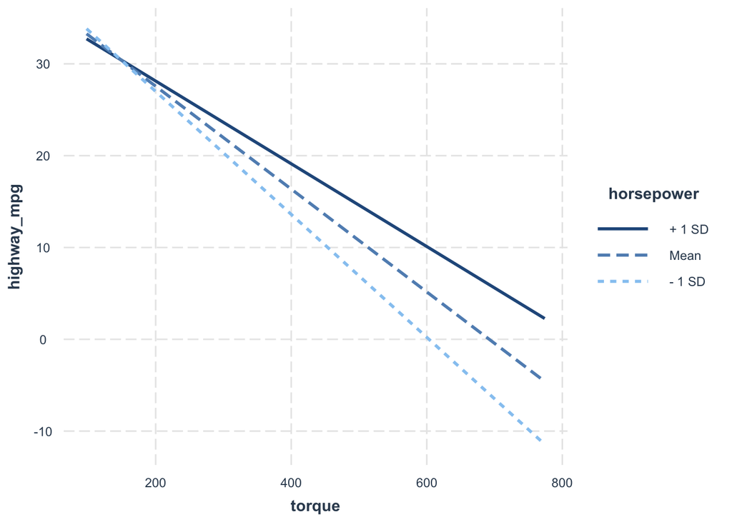

```r
#interaction plot
library(interactions)
cars2$ID_year <- as.factor(cars2$ID_year)
interact_plot(reg2,pred = torque, modx = horsepower,data = cars2,na.rm = TRUE)
```

For the horsepower values, I chose 3 values which are mean, mean+SD, and mean-SD.

5. Calculate beta_hat using matrix algebra

```r
library(Matrix)

Y <- cars2$highway_mpg
Y <- as.matrix(Y)
```

```r
X <- cbind(cars2$horsepower, cars2$torque, cars2$height, cars2$length, cars2$width, as.factor(cars2$ID_year))
X<- as.matrix(X)

X<-cbind(rep(1,4591),X)
```

```r
Xt<-t(X)
```

```r
XtX <- Xt %*% X
```

```r
XtY <- Xt %*% Y
```

```r
XtXinv <- solve(XtX)
```

```r
#b = (X'X)\^-1X'Y
b<- XtXinv %*% Xt %*% Y
b
```

```
##               [,1]
## [1,] 30.2366656562
## [2,]  0.0165738493
## [3,] -0.0510155026
## [4,]  0.0098205080
## [5,]  0.0016162270
## [6,] -0.0004418676
## [7,]  0.8145434026
```

The estimated beta hats using matrix algebra is very similar to the reg model above.

## Problem 3 - Stata

#Import dataset

. import delimited “K:\STATS 506\PS 2\cars.csv” (encoding automatically selected: ISO-8859-1) (18 vars, 5,076 obs)

#a) Rename the columns

. rename dimensionsheight height

. rename dimensionslength length

. rename dimensionswidth width

. rename engineinformationdriveline driveline

. rename engineinformationenginetype enginetype

. rename engineinformationhybrid hybrid

. rename engineinformationnumberofforward fwdgears

. rename engineinformationtransmission transmission

. rename fuelinformationcitympg city_mpg

. rename enginetype engine_type

. rename fuelinformationfueltype fuel_type

. rename fuelinformationhighwaympg highway_mpg

. rename identificationclassification classification

. rename identificationid ID

. rename identificationmake ID_make

. rename identificationmodelyear ID_modelyear

. rename identificationyear ID_year

. rename engineinformationenginestatistic horsepower

. rename v18 torque

#b) Restrict the data to only fuel type is Gasoline

. keep if fuel_type == “Gasoline”

(485 observations deleted)

. preserve

#c) Regression

. regress city_mpg horsepower torque height length width i.ID_year c.horsepower##c.torque

note: horsepower omitted because of collinearity.

note: torque omitted because of collinearity.

Source | SS df MS Number of obs = 4,591

-------------+---------------------------------- F(9, 4581) = 1457.94

Model | 57143.6855 9 6349.29839 Prob > F = 0.0000

Residual | 19950.2243 4,581 4.3549933 R-squared = 0.7412

-------------+---------------------------------- Adj R-squared = 0.7407

Total | 77093.9098 4,590 16.7960588 Root MSE = 2.0869

---------------------------------------------------------------------------------------

city_mpg | Coefficient Std. err. t P>|t|
$$95% conf. interval$$

----------------------+----------------------------------------------------------------

horsepower | -.0255072 .0012229 -20.86 0.000 -.0279046 -.0231098

torque | -.0629598 .0012202 -51.60 0.000 -.065352 -.0605677

height | .0034468 .0005152 6.69 0.000 .0024368 .0044569

length | .0008426 .0004007 2.10 0.036 .0000571 .0016281

width | .0016413 .0004104 4.00 0.000 .0008366 .0024459

|

ID_year |

2010 | -.9130529 .3069012 -2.98 0.003 -1.514727 -.3113788

2011 | -.5060647 .3063918 -1.65 0.099 -1.10674 .0946109

2012 | .1406594 .3087974 0.46 0.649 -.4647324 .7460512

|

horsepower | 0 (omitted)

torque | 0 (omitted)

|

c.horsepower#c.torque | .0000943 2.23e-06 42.28 0.000 .0000899 .0000986

|

_cons | 33.57215 .3819709 87.89 0.000 32.8233 34.32099

---------------------------------------------------------------------------------------

#d) Regression with the interaction term

. regress highway_mpg horsepower torque height length width i.ID_year c.torque##c.horsepower

note: torque omitted because of collinearity.

note: horsepower omitted because of collinearity.

Source | SS df MS Number of obs = 4,591

-------------+---------------------------------- F(9, 4581) = 480.07

Model | 81105.8715 9 9011.76351 Prob > F = 0.0000

Residual | 85993.096 4,581 18.7716865 R-squared = 0.4854

-------------+---------------------------------- Adj R-squared = 0.4844

Total | 167098.968 4,590 36.4050038 Root MSE = 4.3326

---------------------------------------------------------------------------------------

highway_mpg | Coefficient Std. err. t P>|t|
$$95% conf. interval$$

----------------------+----------------------------------------------------------------

horsepower | -.0166633 .0025388 -6.56 0.000 -.0216406 -.011686

torque | -.0860593 .0025333 -33.97 0.000 -.0910257 -.0810928

height | .0065604 .0010696 6.13 0.000 .0044634 .0086573

length | .0017767 .0008318 2.14 0.033 .0001459 .0034075

width | -.0011694 .0008521 -1.37 0.170 -.00284 .0005011

|

ID_year |

2010 | -.5627858 .6371716 -0.88 0.377 -1.811949 .6863777

2011 | .0725356 .6361142 0.11 0.909 -1.174555 1.319626

2012 | 1.197033 .6411085 1.87 0.062 -.0598488 2.453915

|

torque | 0 (omitted)

horsepower | 0 (omitted)

|

c.torque#c.horsepower | .0001124 4.63e-06 24.28 0.000 .0001033 .0001214

|

_cons | 42.18795 .7930274 53.20 0.000 40.63323 43.74266

---------------------------------------------------------------------------------------